# Grupo 4: Percepción de inseguridad en Lima Metropolitana

# Análisis de la percepción de inseguridad en Lima Metropolitana

#### Integrantes

##### Adriana Berenice Mosqueira Carrión

##### Addier Giovanni Arriola Laura

## 1. Planteamiento del problema

### La percepción de inseguridad se entienden como la posibilidad de que ocurra algún hecho delictivo o el temor de ser víctimas de estos hechos (Costa y Romero 2011). Esta percepción de inseguridad se suele medir a través de encuestas y sirven para elaborar mejores políticas de seguridad pública focalizadas en aquellos lugares con altos índices de violencia o percepción de la misma. Desde la academia, el análisis de este fenómeno se ha concentrado en el uso de estadísticas elaboradas por sectores universitarios o privados, tales como los estudios de Costa y Romero (2011), Lopez (2014). Asimismo, estos estudios se han concentrado en analizar la tendencia de este fenómeno durante la primera década del siglo XX.

### No obstante, a partir de la segunda década, la producción sobre este fenómeno ha sido escasa. Este hecho resalta aún más debido a la existencia de data estadística producida por el Estado peruano, tal como la Encuesta Nacional Especializada sobre Victimización del 2017. Esta encuesta cuenta con valiosa información desagregada por sectores geográficos, lo cual permitiría focalizar mejor las respuesta del Estado en materia de seguridad ciudadana. Además, permitiría comprender de mejor manera, qué tipo de delitos causan mayor temor o sensación de inseguridad en determinados espacios geográficos de la ciudad de Lima.

### En ese sentido, el presente informe tiene como objetivo identificar las zonas de Lima con mayor grado de sensación de inseguridad e identificar el grado de inseguridad que generan los delitos patrimoniales (robo). Asimismo, se propone crear un indicador compuesto de sensación de inseguridad ciudadana de delitos patrimoniales para los distritos de la capital limeña.

## 2. Pregunta de investigación

### ¿Cuáles son los niveles de percepción de inseguridad respecto a los delitos patrimoniales en los distritos de Lima Metropolitana en el año 2017?

## 3. Objetivo principal

### Identificar los niveles de percepción de inseguridad respecto a los delitos patrimoniales en los distritos de Lima Metropolitana en el año 2017

## 4. Objetivos secundarios

### - Identificar las zonas con mayor nivel de percepción de inseguridad respecto a los delitos patrimoniales en Lima Metropolitana en el año 2017

### - Identificar la percepción de inseguridad respecto a los delitos patrimoniales en Lima Metropolitana en el año 2017

### - Proponer un indicador compuesto de percepción de inseguridad respecto a los delitos patrimoniales para los distritos de Lima Metropolitana

## Análisis exploratorio de las variables a utilizar

### Base en GitHub

```r
library(dplyr)
library(tidyverse)
library(rio)
library(lubridate)
library(data.table)
```

```r
library(ggplot2)
library(dplyr)
```

```r
link_lima="https://github.com/AdrianaMosqueira/Grupo4_Victimizacion_Lima/raw/main/Data/vict_lima.csv"
```

```r
lima = import(link_lima)
```

### Explorando la data y variables a utilizar

```r
class(lima)
```

```
## [1] "data.frame"
```

```r
dim(lima)
```

```
## [1] 14716   188
```

```r
lima= lima |>
  mutate(Zona=
           case_when(NOMBREDI %in% c("SANTA ROSA","PUENTE PIEDRA","ANCON","CARABAYLLO", "INDEPENDENCIA","COMAS","SAN MARTIN DE PORRES","LOS OLIVOS")~"LIMA NORTE",
                     NOMBREDI %in% c("RIMAC","LA VICTORIA","LIMA","BREÑA","SAN LUIS")~"LIMA CENTRO",
                     NOMBREDI %in% c("BARRANCO","SURQUILLO","LINCE","MAGDALENA DEL MAR","SANTIAGO DE SURCO","SAN MIGUEL","LA MOLINA","JESUS MARIA", "PUEBLO LIBRE","SAN BORJA","MIRAFLORES","SAN ISIDRO")~"LIMA MODERNA",
                     NOMBREDI %in% c("LURIGANCHO","SAN JUAN DE LURIGANCHO","ATE","EL AGUSTINO","SANTA ANITA","CHACLACAYO")~"LIMA ESTE",
                     NOMBREDI %in% c("CHORRILLOS","LURIN","PACHACAMAC","PUCUSANA","PUNTA HERMOSA","SAN JUAN DE MIRAFLORES","VILLA EL SALVADOR","VILLA MARIA DEL TRIUNFO")~"LIMA SUR",
                     FALSE~"Ninguno"))


table(lima$Zona)
```

```
##
##  LIMA CENTRO    LIMA ESTE LIMA MODERNA   LIMA NORTE     LIMA SUR
##         1633         2848         4366         3054         2470
```

### En cuanto a la distribución de la población encuestada, se identifica que el grueso de esta se encuentra en la zona de Lima Moderna (4366), seguido por todos aquellos distritos que conforman Lima Norte (3054). Mientras que aquellla zona con una distribución menor corresponde a todos aquellos distritos que conforman Lima Centro (1633).

```r
lima$NOMBREDI = gsub("Ã‘", "Ñ", lima$NOMBREDI)
```

```r
lima$Sexo <- factor(lima$Sexo,
                          labels = c("Hombre", "Mujer")) # Respetar el orden
levels(lima$Sexo)
```

```
## [1] "Hombre" "Mujer"
```

## Victimización por zonas y por sexo en Lima Metropolitana

### La victimización se encuentra por encima del 80% en todos los sectores de Lima Metropolitana. Aunque, se puede puntualizar algunas diferencias. Por ejemplo, la zona con mayor porcentaje de vicitmización es Lima Norte (88.83%) y Lima Este (88.59%), mientras que la zona con el menor porcentaje de victimización es la de Lima Moderna (80.07%).

```r
lima$victima_delito <- factor(lima$victima_delito,
                          labels = c("Sí", "No")) # Respetar el orden
levels(lima$victima_delito)
```

```
## [1] "Sí" "No"
```

```r
library(scales)
```

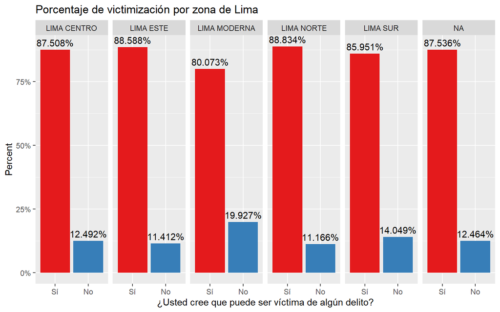

```r
lima |>
  ggplot(aes(x= victima_delito,  group=Zona)) +
  geom_bar(aes(y = ..prop.., fill = factor(..x..)), stat="count") +
  geom_text(aes( label = scales::percent(..prop..),y= ..prop.. ), stat= "count", vjust = -.5) +
  labs(y = "Percent", fill="¿Usted cree ser víctima de algún delito?") +
  facet_grid(~Zona) +
  scale_y_continuous(labels=percent)+
  labs(title="Porcentaje de victimización por zona de Lima", x="¿Usted cree que puede ser víctima de algún delito?")+
  scale_fill_brewer(palette = "Set1") +
  theme(legend.position = "bottom")+
  theme(legend.position = "none")
```

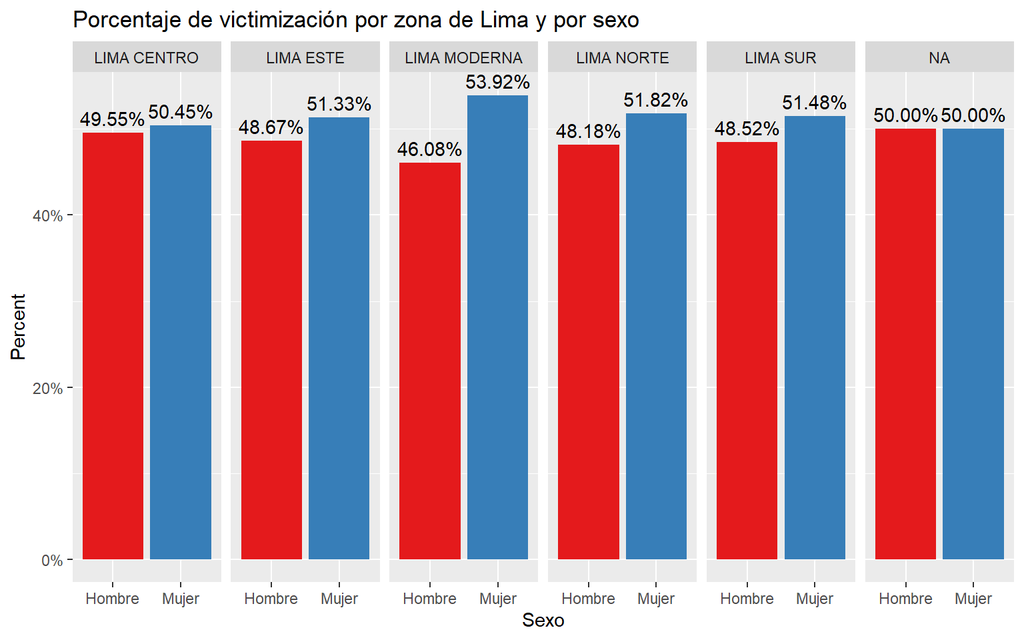

```r
vict_sexo <- lima[lima$victima_delito %in% c("Sí"),]
vict_sexo |>
  ggplot(aes(x= Sexo,  group= victima_delito)) +
  geom_bar(aes(y = ..prop.., fill = factor(..x..)), stat="count") +
  geom_text(aes( label = scales::percent(..prop..),y= ..prop.. ), stat= "count", vjust = -.5) +
  labs(y = "Percent", fill="Sexo") +
  facet_grid(~Zona) +
  scale_y_continuous(labels=percent)+
  labs(title="Porcentaje de victimización por zona de Lima y por sexo", x="Sexo")+
  scale_fill_brewer(palette = "Set1") +
  theme(legend.position = "bottom")+
  theme(legend.position = "none")
```

## Victimización por robo de vehículo

### En el caso del robo de vehículo, existe una clara diferencia entre Lima Moderna y el resto de sectores de Lima Metropolitana. En Lima Moderna cerca del 30% de encuestados manifestaron que sí sienten que pueden ser víctimas del robo de su vehículo, mientras que en otros sectores limeños, esta sensación no pasa del 15% de encuestados.

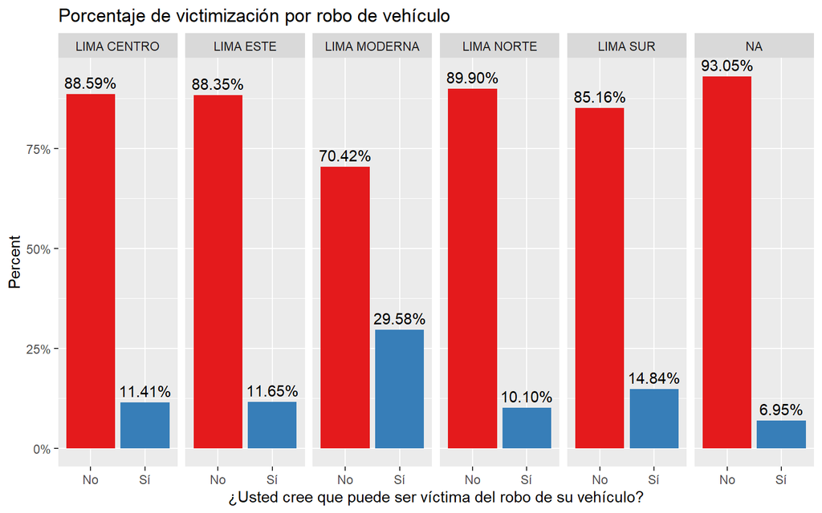

```r
lima |>
  filter(!is.na(Robo_vehiculo)) |>
  ggplot(mapping = aes(x= Robo_vehiculo,  group=Zona)) +
  geom_bar(aes(y = ..prop.., fill = factor(..x..)), stat="count") +
  geom_text(aes( label = scales::percent(..prop..),
                   y= ..prop.. ), stat= "count", vjust = -.5) + labs(y = "Percent", fill="¿Usted cree que puede ser víctima del robo de su vehículo?") + facet_grid(~Zona) + scale_y_continuous(labels=percent)+labs(title="Porcentaje de victimización por robo de vehículo", x="¿Usted cree que puede ser víctima del robo de su vehículo?")+ scale_fill_brewer(palette = "Set1")+theme(legend.position = "bottom")+theme(legend.position = "none")
```

### Además al analizar la victimización por robo de vehículo, por sexo, se encontró que existe una mayor percepción de inseguridad por parte de las hombres, principalmente en las zonas de Lima este, donde el 60.54% de hombres señala sentirse más propensos a ser sufrir el robo de sus vehículos, mientras que el porcentaje de mujeres es de 39.46%. Este porcentaje, para los hombres, es mayor en Lima norte (61.68%), mientras que para las mujeres es menor (38.32%).

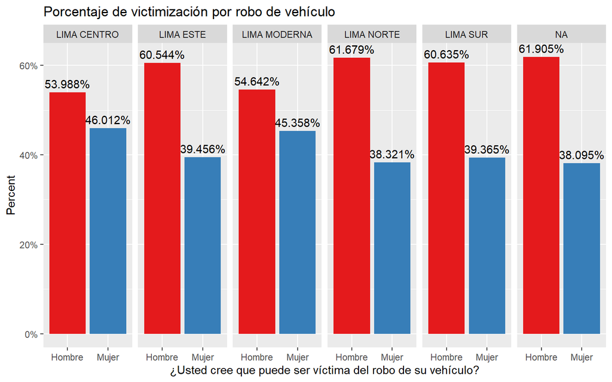

```r
vehi_sexo <- lima[lima$Robo_vehiculo %in% c("Sí"),]
vehi_sexo |>
  filter(!is.na(Robo_vehiculo)) |>
  ggplot(mapping = aes(x=Sexo ,  group=Robo_vehiculo)) +
  geom_bar(aes(y = ..prop.., fill = factor(..x..)), stat="count") +
  geom_text(aes( label = scales::percent(..prop..),
                   y= ..prop.. ), stat= "count", vjust = -.5) + labs(y = "Percent", fill="¿Usted cree que puede ser víctima del robo de su vehículo?") + facet_grid(~Zona) + scale_y_continuous(labels=percent)+labs(title="Porcentaje de victimización por robo de vehículo", x="¿Usted cree que puede ser víctima del robo de su vehículo?")+ scale_fill_brewer(palette = "Set1")+theme(legend.position = "bottom")+theme(legend.position = "none")
```

## Victimización por robo de vivienda

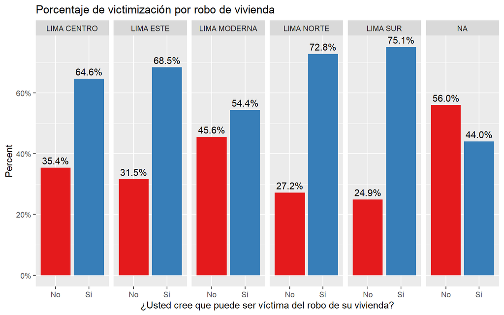

```r
lima |>
  filter(!is.na(Robo_vivienda)) |>
  ggplot(lima, mapping = aes(x= Robo_vivienda,  group=Zona)) +
  geom_bar(aes(y = ..prop.., fill = factor(..x..)), stat="count") +
  geom_text(aes( label = scales::percent(..prop..),
                   y= ..prop.. ), stat= "count", vjust = -.5) + labs(y = "Percent", fill="¿Usted cree que puede ser víctima del robo de su vehículo?") + facet_grid(~Zona) + scale_y_continuous(labels=percent)+labs(title="Porcentaje de victimización por robo de vivienda", x="¿Usted cree que puede ser víctima del robo de su vivienda?")+ scale_fill_brewer(palette = "Set1")+theme(legend.position = "bottom")+theme(legend.position = "none")
```

### Además, al realizar el análisis por sexo, se identifica una mayor percepción de victimización por robo de vivienda por parte de las mujeres en todas las zonas, principalmente en Lima moderna, donde la diferencia entre hombres (44.25%) y mujeres (55.75%) es de 11.5%. Mientras que la zona que muestra una menor diferencia es Lima sur, con 1.94%. Las demás zonas muestran en promedio una diferencia del 5.06%.

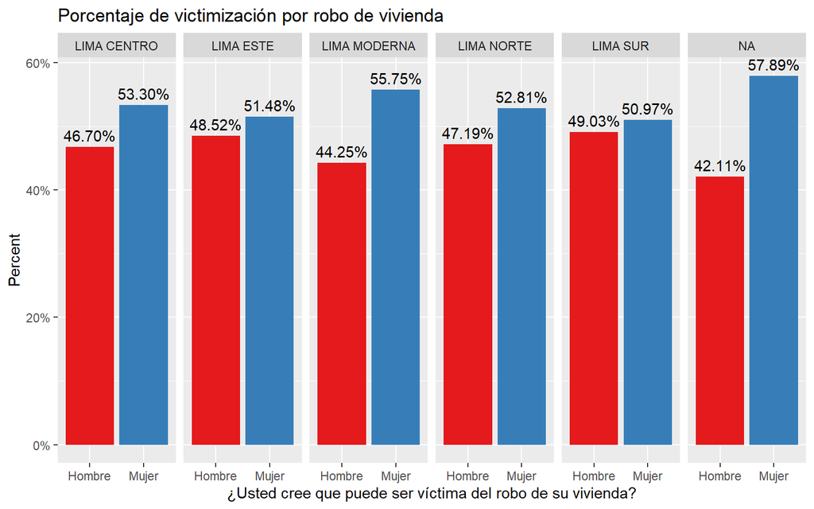

```r
vivi_sexo <- lima[lima$Robo_vivienda %in% c("Sí"),]

vivi_sexo |>
  filter(!is.na(Robo_vivienda)) |>
  ggplot(lima, mapping = aes(x= Sexo,  group=Robo_vivienda)) +
  geom_bar(aes(y = ..prop.., fill = factor(..x..)), stat="count") +
  geom_text(aes( label = scales::percent(..prop..),
                   y= ..prop.. ), stat= "count", vjust = -.5) + labs(y = "Percent", fill="¿Usted cree que puede ser víctima del robo de su vehículo?") + facet_grid(~Zona) + scale_y_continuous(labels=percent)+labs(title="Porcentaje de victimización por robo de vivienda", x="¿Usted cree que puede ser víctima del robo de su vivienda?")+ scale_fill_brewer(palette = "Set1")+theme(legend.position = "bottom")+theme(legend.position = "none")
```

## Victimización por robo sin violencia

### En el caso del robo sin violencia, se aprecia que en el sector de Lima Este y Lima Norte se encuentra el mayor porcentaje de victimización con 83.9% y 82.2%, respectivamente. Mientras que los niveles son menores en el caso de Lima Sur y Lima centro, aunque con más del 70%.

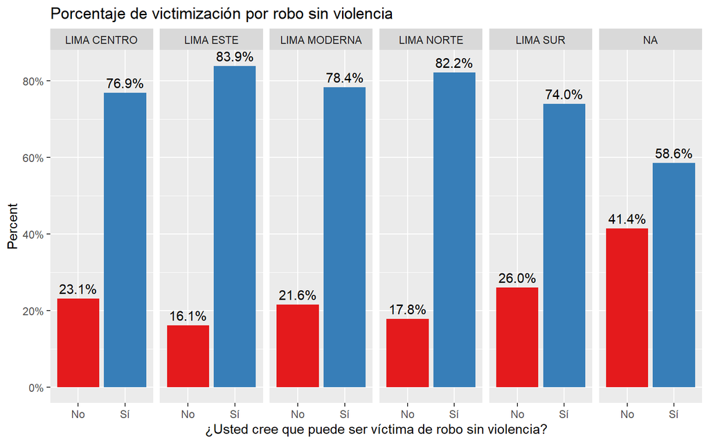

```r
lima |>
  filter(!is.na(Robo_sinviolencia)) |>
  ggplot(lima, mapping = aes(x= Robo_sinviolencia,  group=Zona)) +
  geom_bar(aes(y = ..prop.., fill = factor(..x..)), stat="count") +
  geom_text(aes( label = scales::percent(..prop..),
                   y= ..prop.. ), stat= "count", vjust = -.5) + labs(y = "Percent", fill="¿Usted cree que puede ser víctima de robo sin violencia?") + facet_grid(~Zona) + scale_y_continuous(labels=percent)+labs(title="Porcentaje de victimización por robo sin violencia", x="¿Usted cree que puede ser víctima de robo sin violencia?")+ scale_fill_brewer(palette = "Set1")+theme(legend.position = "bottom")+theme(legend.position = "none")
```

### Además, al realizar el análisis por sexo, se identifica una mayor percepción de victimización por parte de las mujeres en todas las zonas de Lima Metropolitana. Destaca nuevamente el caso de Lima Moderna con una diferencia de más del 10%.

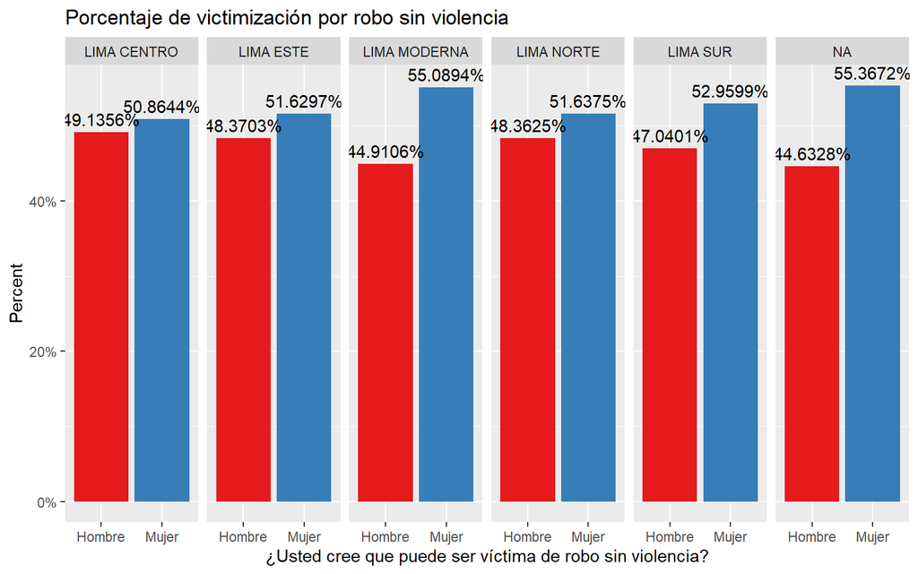

```r
robosinviol_sexo <- lima[lima$Robo_sinviolencia %in% c("Sí"),]

robosinviol_sexo |>
  filter(!is.na(Robo_sinviolencia)) |>
  ggplot(lima, mapping = aes(x= Sexo,  group=Robo_sinviolencia)) +
  geom_bar(aes(y = ..prop.., fill = factor(..x..)), stat="count") +
  geom_text(aes( label = scales::percent(..prop..),
                   y= ..prop.. ), stat= "count", vjust = -.5) + labs(y = "Percent", fill="¿Usted cree que puede ser víctima de robo sin violencia?") + facet_grid(~Zona) + scale_y_continuous(labels=percent)+labs(title="Porcentaje de victimización por robo sin violencia", x="¿Usted cree que puede ser víctima de robo sin violencia?")+ scale_fill_brewer(palette = "Set1")+theme(legend.position = "bottom")+theme(legend.position = "none")
```

## Victimización por robo con violencia

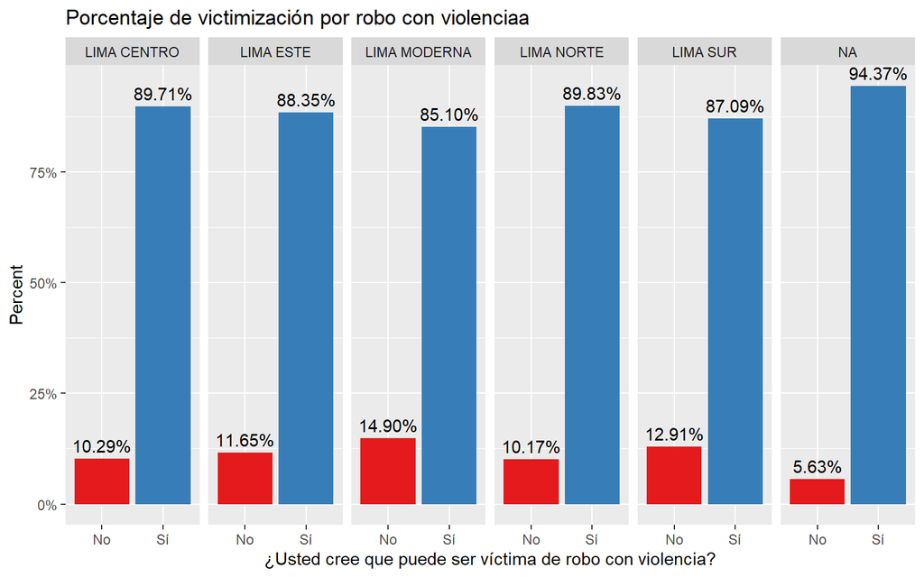

```r
lima |>
  filter(!is.na(Robo_conviolencia)) |>
  ggplot(lima, mapping = aes(x= Robo_conviolencia,  group=Zona)) +
  geom_bar(aes(y = ..prop.., fill = factor(..x..)), stat="count") +
  geom_text(aes( label = scales::percent(..prop..),
                   y= ..prop.. ), stat= "count", vjust = -.5) + labs(y = "Percent", fill="¿Usted cree que puede ser víctima de robo con violencia?") + facet_grid(~Zona) + scale_y_continuous(labels=percent)+labs(title="Porcentaje de victimización por robo con violenciaa", x="¿Usted cree que puede ser víctima de robo con violencia?")+ scale_fill_brewer(palette = "Set1")+theme(legend.position = "bottom")+theme(legend.position = "none")
```

### Además, al realizar el análisis por sexo, se identifica una mayor percepción de victimización por parte de las mujeres en todas las zonas de Lima Metropolitana, excepto Lima Centro. Destaca nuevamente el caso de Lima Moderna con una diferencia de cerca al 10%.

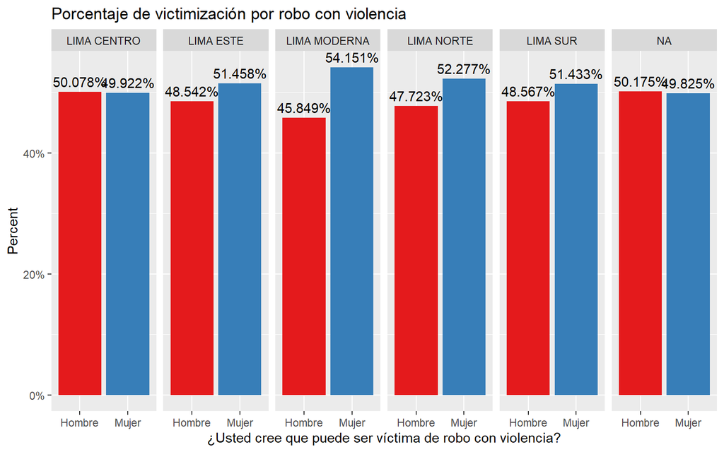

```r
roboconviol_sexo <- lima[lima$Robo_conviolencia %in% c("Sí"),]

roboconviol_sexo |>
  filter(!is.na(Robo_conviolencia)) |>
  ggplot(lima, mapping = aes(x= Sexo,  group=Robo_conviolencia)) +
  geom_bar(aes(y = ..prop.., fill = factor(..x..)), stat="count") +
  geom_text(aes( label = scales::percent(..prop..),
                   y= ..prop.. ), stat= "count", vjust = -.5) + labs(y = "Percent", fill="¿Usted cree que puede ser víctima de robo con violencia?") + facet_grid(~Zona) + scale_y_continuous(labels=percent)+labs(title="Porcentaje de victimización por robo con violencia", x="¿Usted cree que puede ser víctima de robo con violencia?")+ scale_fill_brewer(palette = "Set1")+theme(legend.position = "bottom")+theme(legend.position = "none")
```

# Construyendo un indicador de percepción de inseguridad en Lima Metropolitana por distrito

## Primero contruimos nuestra base de datos por distrito

## Siente inseguridad - victimización

```r
d_vict = vict |>
    filter(victima_delito == "Sí") |>
    group_by(NOMBREDI) |>
    summarise(victima_delito = n())
d_vict
```

```
## # A tibble: 39 x 2
##    NOMBREDI      victima_delito
##    <chr>                  <int>
##  1 ANCON                    300
##  2 ATE                      452
##  3 BARRANCO                 246
##  4 BREÑA                    302
##  5 CARABAYLLO               384
##  6 CHACLACAYO               267
##  7 CHORRILLOS               314
##  8 COMAS                    463
##  9 EL AGUSTINO              362
## 10 INDEPENDENCIA            344
## # ... with 29 more rows
```

## Siente que puede ser víctima de robo de su vehículo

```r
d_vehiculo = vehiculo |>
    filter(Robo_vehiculo == "Sí") |>
    group_by(NOMBREDI) |>
    summarise(Robo_vehiculo = n())
d_vehiculo
```

```
## # A tibble: 37 x 2
##    NOMBREDI      Robo_vehiculo
##    <chr>                 <int>
##  1 ANCON                    20
##  2 ATE                      44
##  3 BARRANCO                 57
##  4 BREÑA                    21
##  5 CARABAYLLO               34
##  6 CHACLACAYO               40
##  7 CHORRILLOS               61
##  8 COMAS                    45
##  9 EL AGUSTINO              46
## 10 INDEPENDENCIA            28
## # ... with 27 more rows
```

## Siente que puede ser víctima de robo de vivienda

```r
d_vivienda = vivienda |>
    filter(Robo_vivienda == "Sí") |>
    group_by(NOMBREDI) |>
    summarise(Robo_vivienda = n())
d_vivienda
```

```
## # A tibble: 39 x 2
##    NOMBREDI      Robo_vivienda
##    <chr>                 <int>
##  1 ANCON                   250
##  2 ATE                     307
##  3 BARRANCO                146
##  4 BREÑA                   133
##  5 CARABAYLLO              287
##  6 CHACLACAYO              173
##  7 CHORRILLOS              221
##  8 COMAS                   336
##  9 EL AGUSTINO             249
## 10 INDEPENDENCIA           210
## # ... with 29 more rows
```

## Siente que puede ser víctima de robo sin violencia

```r
d_sinviolencia = sin_violencia |>
    filter(Robo_sinviolencia == "Sí") |>
    group_by(NOMBREDI) |>
    summarise(Robo_sinviolencia = n())
d_sinviolencia
```

```
## # A tibble: 39 x 2
##    NOMBREDI      Robo_sinviolencia
##    <chr>                     <int>
##  1 ANCON                       255
##  2 ATE                         401
##  3 BARRANCO                    195
##  4 BREÑA                       177
##  5 CARABAYLLO                  313
##  6 CHACLACAYO                  212
##  7 CHORRILLOS                  221
##  8 COMAS                       398
##  9 EL AGUSTINO                 303
## 10 INDEPENDENCIA               251
## # ... with 29 more rows
```

## Siente que puede ser víctima de robo con violencia

```r
d_conviolencia = con_violencia |>
    filter(Robo_conviolencia == "Sí") |>
    group_by(NOMBREDI) |>
    summarise(Robo_conviolencia = n())
d_conviolencia
```

```
## # A tibble: 39 x 2
##    NOMBREDI      Robo_conviolencia
##    <chr>                     <int>
##  1 ANCON                       272
##  2 ATE                         364
##  3 BARRANCO                    221
##  4 BREÑA                       285
##  5 CARABAYLLO                  341
##  6 CHACLACAYO                  219
##  7 CHORRILLOS                  278
##  8 COMAS                       413
##  9 EL AGUSTINO                 345
## 10 INDEPENDENCIA               317
## # ... with 29 more rows
```

## Hacemos el merge

```r
base_2 <- merge(base_1, d_vivienda, by.x = "NOMBREDI",
             by.y = "NOMBREDI", all.x = TRUE, all.y = FALSE)
```

```r
base_3 <- merge(base_2, d_sinviolencia, by.x = "NOMBREDI",
             by.y = "NOMBREDI", all.x = TRUE, all.y = FALSE)
```

```r
vict_dist <- merge(base_3, d_conviolencia, by.x = "NOMBREDI",
             by.y = "NOMBREDI", all.x = TRUE, all.y = FALSE)

vict_dist[is.na(vict_dist)] <- 0
```

## Luego, empezamos explorando nuestras variables

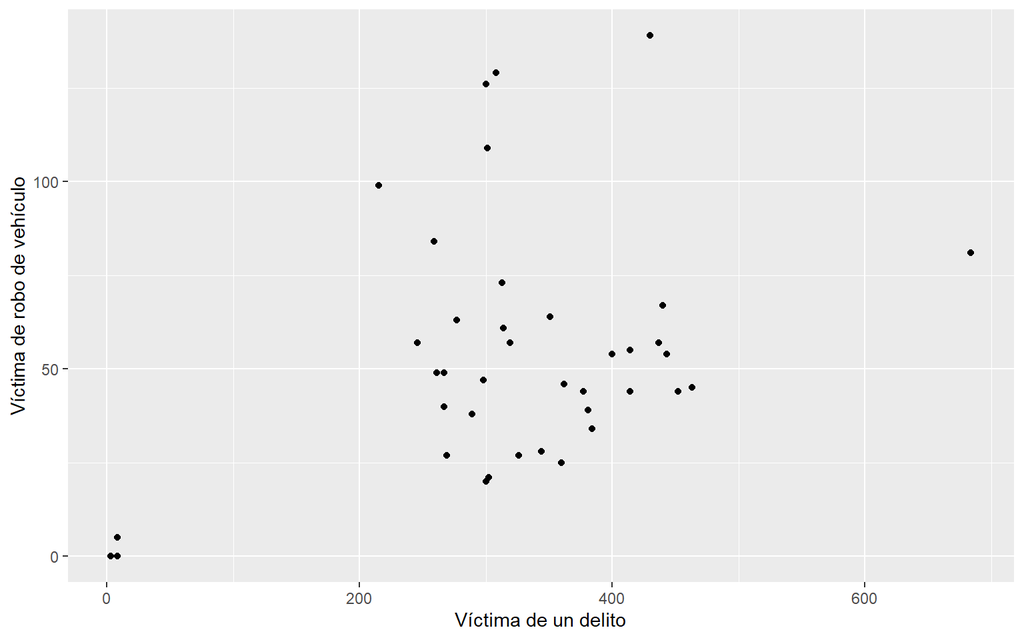

```r
vict_dist |>
  ggplot(aes(x = victima_delito, y = Robo_vehiculo))+
  geom_point() +
  labs( x = "Víctima de un delito", y = "Víctima de robo de vehículo")
```

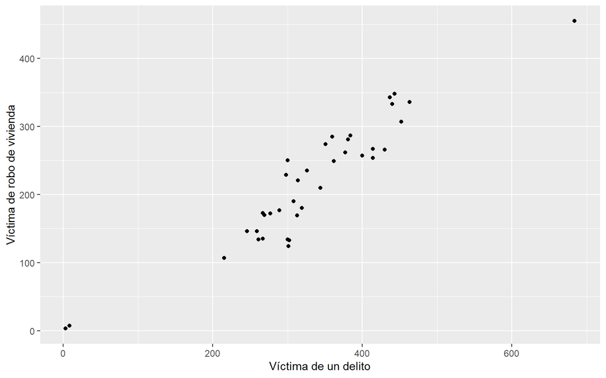

```r
vict_dist |>
  ggplot(aes(x = victima_delito, y = Robo_vivienda))+
  geom_point()+
  labs( x = "Víctima de un delito", y = "Víctima de robo de vivienda")
```

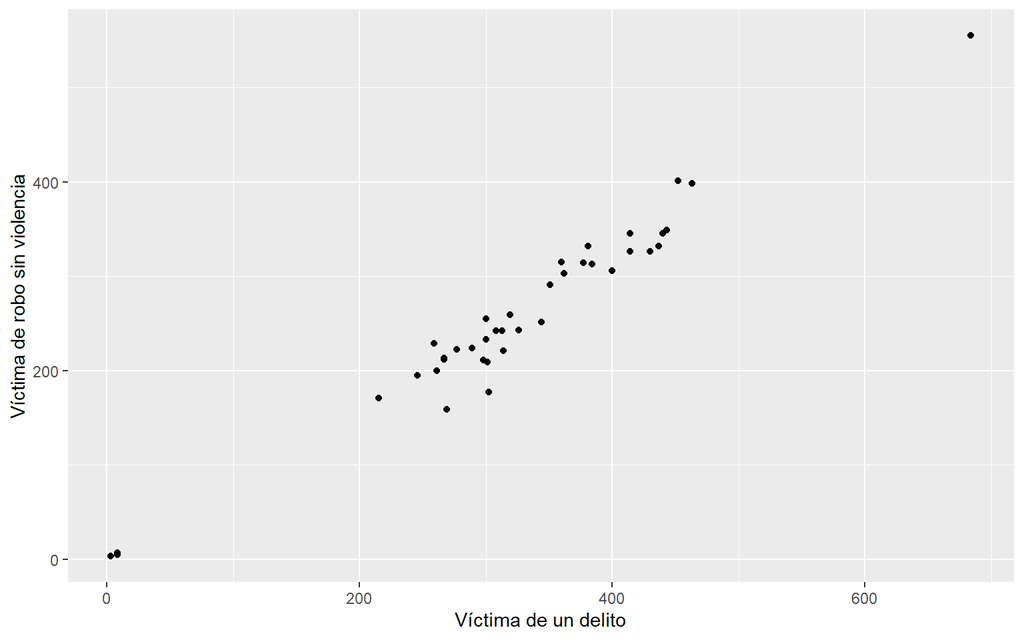

```r
vict_dist |>
  ggplot(aes(x = victima_delito, y = Robo_sinviolencia))+
  geom_point() +
  labs( x = "Víctima de un delito", y = "Víctima de robo sin violencia")
```

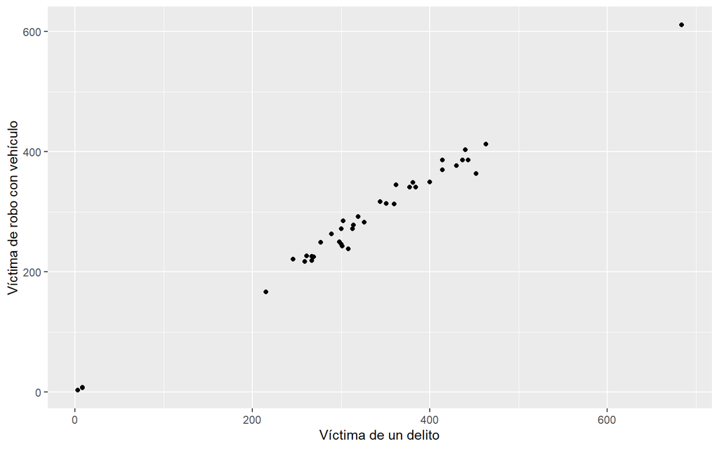

```r
vict_dist |>
  ggplot(aes(x = victima_delito, y = Robo_conviolencia))+
  geom_point() +
  labs( x = "Víctima de un delito", y = "Víctima de robo con vehículo")
```

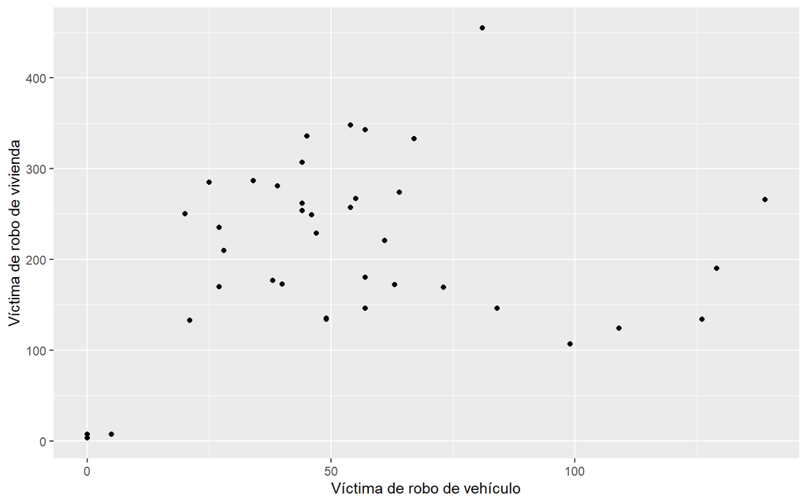

```r
vict_dist |>
  ggplot(aes(x = Robo_vehiculo, y = Robo_vivienda))+
  geom_point() +
  labs( x = "Víctima de robo de vehículo", y = "Víctima de robo de vivienda")
```

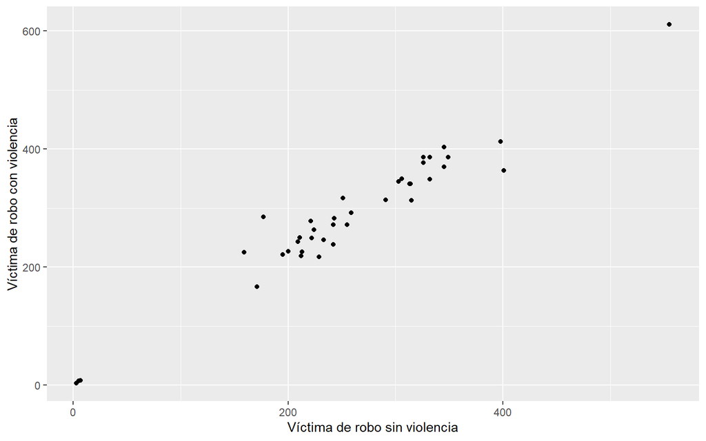

```r
vict_dist |>
  ggplot(aes(x = Robo_sinviolencia, y = Robo_conviolencia))+
  geom_point()+
  labs( x = "Víctima de robo sin violencia", y = "Víctima de robo con violencia")
```

### Parece existir relación entre algunas variables como el ser víctima de un delito y el robo de vivienda; victima de delito y robo sin violencia; victima de delito y robo con violencia; y robo con violencia y sin violencia.

## Ahora, analizamos las relaciones entre las variables

```r
library(psych)
vict_dist <- data.frame(vict_dist)
vict_dist_1 <- vict_dist |>
  select(Robo_vehiculo, Robo_vivienda, Robo_sinviolencia, Robo_conviolencia)
```

```r
corr.test(vict_dist_1)
```

```
## Call:corr.test(x = vict_dist_1)
## Correlation matrix
##                   Robo_vehiculo Robo_vivienda Robo_sinviolencia
## Robo_vehiculo              1.00          0.18              0.33
## Robo_vivienda              0.18          1.00              0.95
## Robo_sinviolencia          0.33          0.95              1.00
## Robo_conviolencia          0.30          0.94              0.97
##                   Robo_conviolencia
## Robo_vehiculo                  0.30
## Robo_vivienda                  0.94
## Robo_sinviolencia              0.97
## Robo_conviolencia              1.00
## Sample Size
## [1] 39
## Probability values (Entries above the diagonal are adjusted for multiple tests.)
##                   Robo_vehiculo Robo_vivienda Robo_sinviolencia
## Robo_vehiculo              0.00          0.27              0.12
## Robo_vivienda              0.27          0.00              0.00
## Robo_sinviolencia          0.04          0.00              0.00
## Robo_conviolencia          0.06          0.00              0.00
##                   Robo_conviolencia
## Robo_vehiculo                  0.13
## Robo_vivienda                  0.00
## Robo_sinviolencia              0.00
## Robo_conviolencia              0.00
##
##  To see confidence intervals of the correlations, print with the short=FALSE option
```

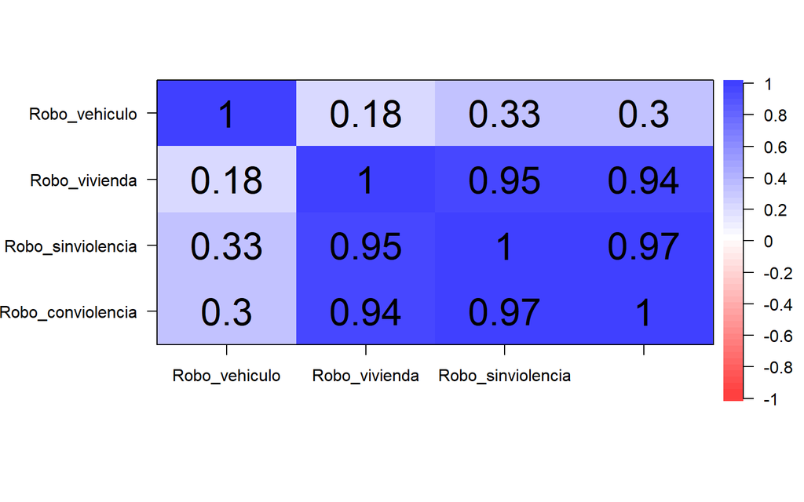

```r
matrixcor <- cor(vict_dist_1)
cor.plot(matrixcor)
```

### El test de correlación y la matriz, nos señala que el robo de vivienda tiene una alta correlación con robo sin violencia y robo con violencia. Además el robo con violencia y sin violencia, también se encuentran altamente relacionados.

```r
KMO(vict_dist_1)
```

```
## Kaiser-Meyer-Olkin factor adequacy
## Call: KMO(r = vict_dist_1)
## Overall MSA =  0.73
## MSA for each item =
##     Robo_vehiculo     Robo_vivienda Robo_sinviolencia Robo_conviolencia
##              0.42              0.78              0.70              0.78
```

### Nuestro Overall MSA es de 0.73 lo cual es bastante aceptable.

```r
library(rela)
library(factoextra)
library(psych)
```

```r
cortest.bartlett(matrixcor, n=dim(vict_dist_1)[1])
```

```
## $chisq
## [1] 201.8835
##
## $p.value
## [1] 7.538329e-41
##
## $df
## [1] 6
```

### El p_value es menor a 0.5, lo cual nos señala que no estamos frente a una matriz de identidad.

## Ahora determinamos el número de componentes

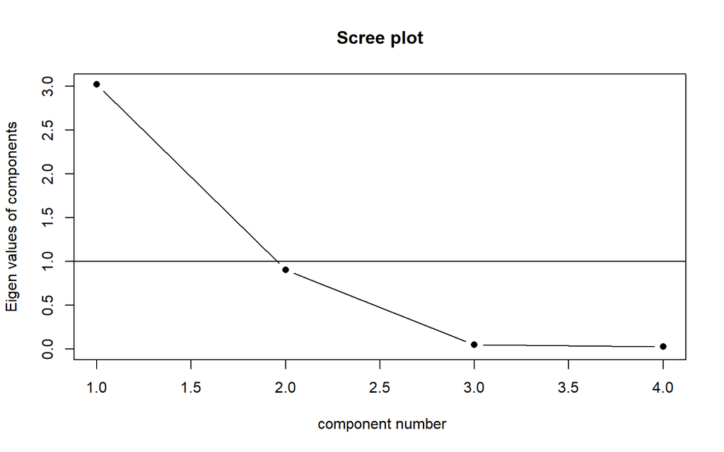

```r
scree(vict_dist_1, pc = TRUE, factor = FALSE)
```

### De acuerdo al gráfico, observamos que el codo está por encima de 1.

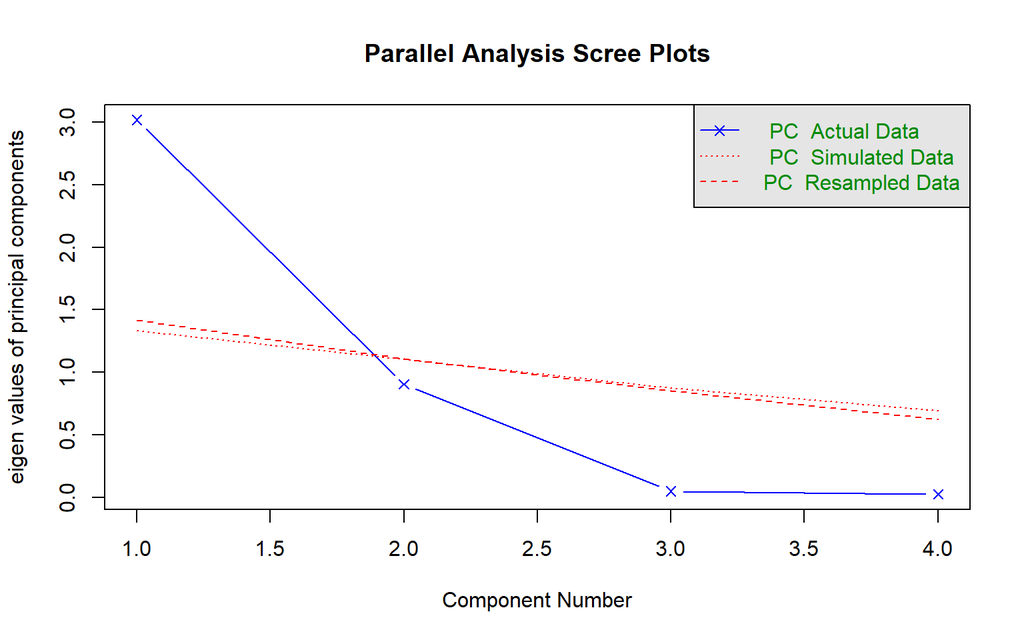

```
## Parallel analysis suggests that the number of factors =  NA  and the number of components =  1
```

```r
fa.parallel(vict_dist_1, fa = "pc")
```

### Nos indica que optemos por 1 componente. Ahora estandarizamos:

```r
pc <- prcomp(x=vict_dist_1,scale=TRUE, center=TRUE)
names(pc)
```

```
## [1] "sdev"     "rotation" "center"   "scale"    "x"
```

# Luego, analizamos los componentes principales calculados

```r
summary(pc)
```

```
## Importance of components:
##                           PC1    PC2     PC3     PC4
## Standard deviation     1.7374 0.9512 0.22573 0.16027
## Proportion of Variance 0.7547 0.2262 0.01274 0.00642
## Cumulative Proportion  0.7547 0.9808 0.99358 1.00000
```

### Observamos que el componente 1 explica aproximadamente el 75%

```r
pc$rotation
```

```
##                         PC1         PC2        PC3        PC4
## Robo_vehiculo     0.2271030 -0.96561812 -0.1162378 -0.0499463
## Robo_vivienda     0.5517710  0.23271416 -0.7831108 -0.1677210
## Robo_sinviolencia 0.5690570  0.06307932  0.2526463  0.7799775
## Robo_conviolencia 0.5658154  0.09719449  0.5562338 -0.6008411
```

### Observamos la relación entre los componentes y las variables. El PC1 tiene relación positiva con todas las variables, siendo la más alta con robo sin violencia y robo con violencia. La más baja es el robo de vehículo.

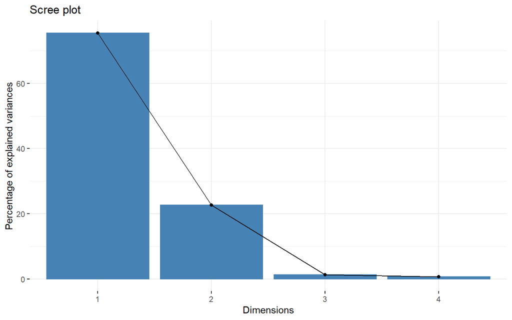

```r
library(factoextra)
fviz_eig(pc)
```

### Ahora observamos graficamente la explicación de cada componente. Como se observa, el Componente 1 explica más del 70%.

```r
pc$x
```

```
##               PC1         PC2          PC3          PC4
##  [1,] -0.07358238  1.08306732 -0.244198398  0.048614320
##  [2,]  1.66178346  0.67636099  0.010487452  0.504111268
##  [3,] -0.98466858 -0.33904697  0.069652920 -0.001211529
##  [4,] -1.08670431  0.73767707  0.573090990 -0.395283544
##  [5,]  0.89016157  0.85172143 -0.115696625  0.026195149
##  [6,] -0.86781924  0.23646431 -0.056791308  0.114185777
##  [7,] -0.10659784 -0.21318244 -0.208040408 -0.246647835
##  [8,]  2.06158128  0.75647252  0.005939689  0.171026092
##  [9,]  0.72371276  0.40349161  0.143783410 -0.021481069
## [10,] -0.04255377  0.78692943  0.260859776 -0.162195564
## [11,] -0.98093663 -0.11397875  0.254355300  0.136402052
## [12,]  0.10356996 -2.31865389 -0.345686648  0.069640170
## [13,]  1.06640619  0.52340531  0.366431351 -0.074297121
## [14,]  0.86584680  0.19232870  0.082473126 -0.051848314
```

[output cut: 25 more lines]

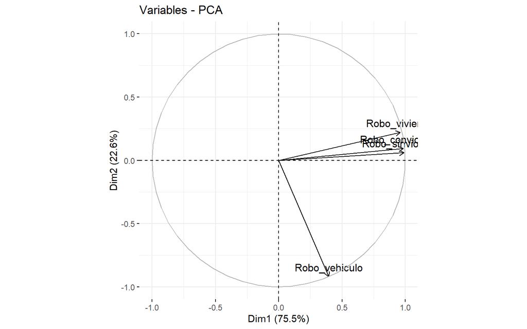

```r
fviz_pca_var(pc)
```

### Agregamos el PC1 a nuestra base final

```r
vict_final <- vict_dist |>
  mutate(pc1 = pc$x[,1])

names(vict_final)[names(vict_final) == 'pc1'] <- 'Indicador'
```

## Tabla de distritos con mayor sensación de inseguridad por delitos patrimoniales

### Observamos que los 5 distritos con mayor percepción de inseguridad por delitos patrimoniales son San Juan de Lurigancho, Comas, San Martín de Porres, Villa María del Triunfo y Santiago de Surco.

```r
library(lubridate)
library(kableExtra)
vict_final |>
  select(NOMBREDI, Indicador) |>
  arrange(desc(Indicador)) |>
  kable() |>
  kable_styling()
```

| NOMBREDI | Indicador |
| --- | --- |
| SAN JUAN DE LURIGANCHO | 4.8201818 |
| COMAS | 2.0615813 |
| SAN MARTIN DE PORRES | 1.8622149 |
| VILLA MARIA DEL TRIUNFO | 1.7939170 |
| SANTIAGO DE SURCO | 1.7499995 |
| VILLA EL SALVADOR | 1.6948165 |
| ATE | 1.6617835 |
| LOS OLIVOS | 1.2392969 |
| LA VICTORIA | 1.0664062 |
| SANTA ANITA | 1.0329934 |
| CARABAYLLO | 0.8901616 |
| LIMA | 0.8658468 |
| LURIGANCHO | 0.8229816 |
| SAN JUAN DE MIRAFLORES | 0.7717668 |
| EL AGUSTINO | 0.7237128 |
| PUENTE PIEDRA | 0.6874687 |
| LA MOLINA | 0.1035700 |
| INDEPENDENCIA | -0.0425538 |
| ANCON | -0.0735824 |
| SAN MIGUEL | -0.0929984 |
| CHORRILLOS | -0.1065978 |
| RIMAC | -0.1199641 |
| SURQUILLO | -0.2355195 |
| SAN BORJA | -0.2440970 |
| LURIN | -0.3518297 |
| LINCE | -0.5102909 |
| MIRAFLORES | -0.5632552 |
| SAN LUIS | -0.5750873 |
| MAGDALENA DEL MAR | -0.6338767 |
| CHACLACAYO | -0.8678192 |
| JESUS MARIA | -0.9809366 |
| BARRANCO | -0.9846686 |
| PUEBLO LIBRE | -1.0516348 |
| BREÑA | -1.0867043 |
| PACHACAMAC | -1.2306972 |
| SAN ISIDRO | -1.3127419 |
| PUNTA HERMOSA | -4.2255537 |
| SANTA ROSA | -4.2445511 |
| PUCUSANA | -4.3137388 |

## Mapa Distrital de Lima Metropolitana

### Para una mejor visualización del indicador

```r
library(geojsonio)
library(sf)
library(ggrepel)
library(tidyverse)
library(rio)
```

```r
link_mapa = "https://github.com/ChristianChiroqueR/banco_de_datos/raw/main/Mapas_Peru/DISTRITOS.json"
spdf <- geojson_read(link_mapa,  what = "sp") #archivo json
peru<-st_as_sf(spdf) # Lo convertimos a tipo sf para mayor facilidad
```

```r
shp_lima <- peru |>
  filter(DEPARTAMEN == "LIMA")
```

```r
#export(shp_lima,"shp_lima.json")
#link_shp_lima="https://github.com/AdrianaMosqueira/Grupo4_Victimizacion_Lima/raw/main/Data/shp_lima.json"
#shp_lima = import(link_shp_lima)
```

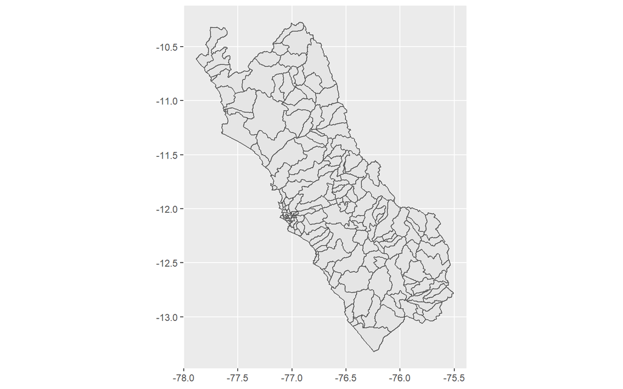

```r
ggplot(data = shp_lima) + geom_sf()
```

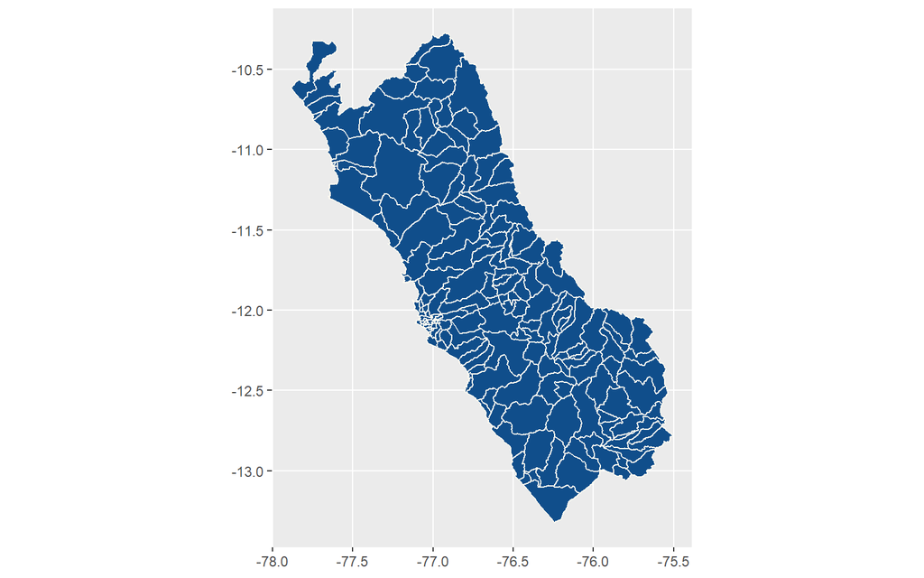

```r
ggplot(data = shp_lima) +
  geom_sf(fill="dodgerblue4", color="floralwhite")
```

```r
names(vict_final)[names(vict_final) == 'NOMBREDI'] <- 'DISTRITO'
```

```r
data_mapa <- shp_lima  |>
  left_join(vict_final)
```

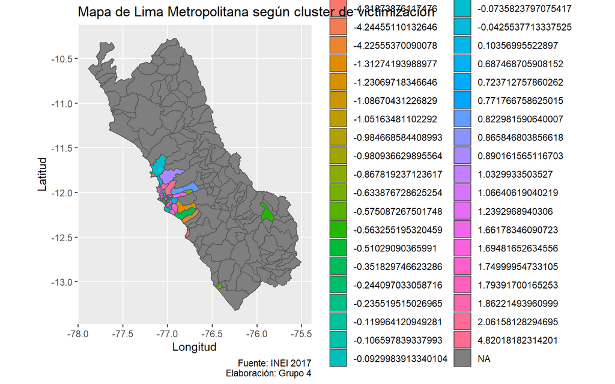

```r
ggplot(data_mapa) +
  geom_sf(aes(fill = as.factor(Indicador)))+
  labs(title = "Mapa de Lima Metropolitana según cluster de victimización",
       caption = "Fuente: INEI 2017
       Elaboración: Grupo 4",
       x="Longitud",
       y="Latitud") +
  scale_fill_discrete(name = "Clusters")
```

# Método no jerárquico (partición por medoides)

```r
library(cluster)
```

```r
library(ggrepel)
library(psych)
library(scatterplot3d)
library(rgl)
#library(NbClust)
```

```r
## Para identificar el número de clusters ideal
#resnumclust<-NbClust(vict_dist_1, distance = "euclidean", min.nc=2, #max.nc=10, method = "ward.D", index = "alllong")
#fviz_nbclust(resnumclust)
```

```r
medoides = vict_dist
```

```r
distancias= daisy(vict_dist_1, metric="gower")
```

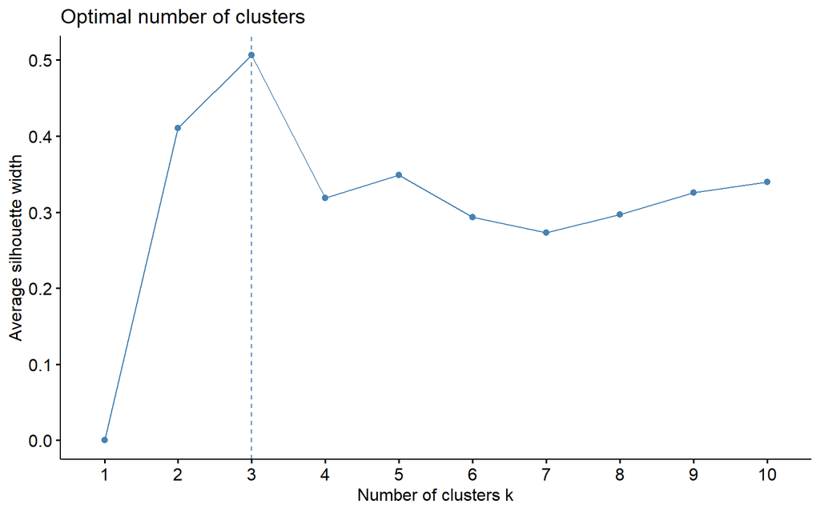

```r
fviz_nbclust(vict_dist_1, pam,diss=distancias,method = "silhouette",k.max = 10,verbose = F)
```

```r
particion = pam(distancias,2,cluster.only = F)
```

```
##   cluster size ave.sil.width
## 1       1   19           0.5
## 2       2   20           0.3
```

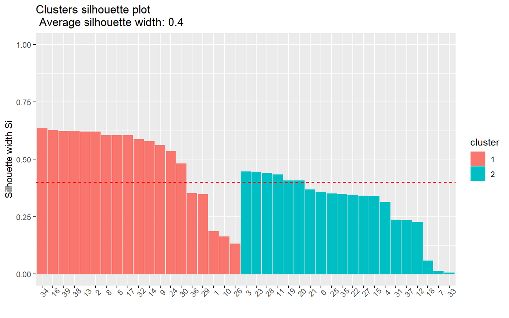

```r
fviz_silhouette(particion, label=TRUE)
```

```r
vict_dist_1 |> mutate(particion=particion$clustering) |>
  group_by(particion) |>
  summarise(
  Robo_vivienda = mean(Robo_vivienda),
  Robo_vehiculo = mean(Robo_vehiculo),
  Robo_sinviolencia=mean(Robo_sinviolencia),
  Robo_conviolencia=mean(Robo_conviolencia))
```

```
## # A tibble: 2 x 5
##   particion Robo_vivienda Robo_vehiculo Robo_sinviolencia Robo_conviolencia
##       <int>         <dbl>         <dbl>             <dbl>             <dbl>
## 1         1          289.          50.9              332.              364.
## 2         2          138.          56.7              182.              207.
```

```r
medoides$particion = particion$clustering
medoides$particion = as.factor(medoides$particion)
levels(medoides$particion) = c("Alto nivel de victimización", "Bajo nivel de victimización")
table(medoides$particion)
```

```
##
## Alto nivel de victimización Bajo nivel de victimización
##                          19                          20
```

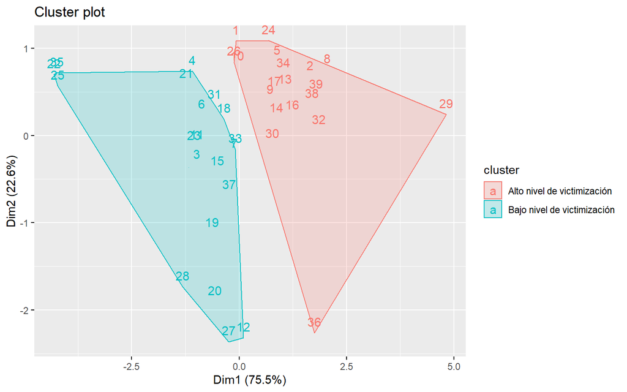

```r
fviz_cluster(object = list(data=vict_dist_1[,1:4], cluster = medoides$particion),
             geom = c("text"),
             ellipse.type = "convex")
```

## Mapa de clasificación por baja o alta victmización (Medoides)

```r
names(medoides)[names(medoides) == 'NOMBREDI'] <- 'DISTRITO'
```

```r
data_mapa1 <- shp_lima  |>
  left_join(medoides)
```

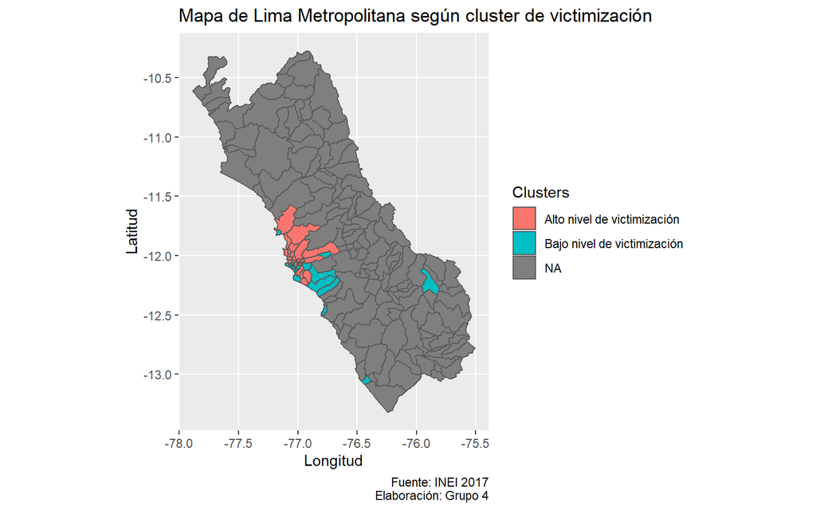

```r
ggplot(data_mapa1) +
  geom_sf(aes(fill = as.factor(particion)))+
  labs(title = "Mapa de Lima Metropolitana según cluster de victimización",
       caption = "Fuente: INEI 2017
       Elaboración: Grupo 4",
       x="Longitud",
       y="Latitud") +
  scale_fill_discrete(name = "Clusters")
```

# Métod Jerárquico (Divisivo)

```r
diana = vict_dist
```

```r
divisivo = hcut(distancias, k = 2,hc_func='diana')
```

```
##   cluster size ave.sil.width
## 1       1   38          0.55
## 2       2    1          0.00
```

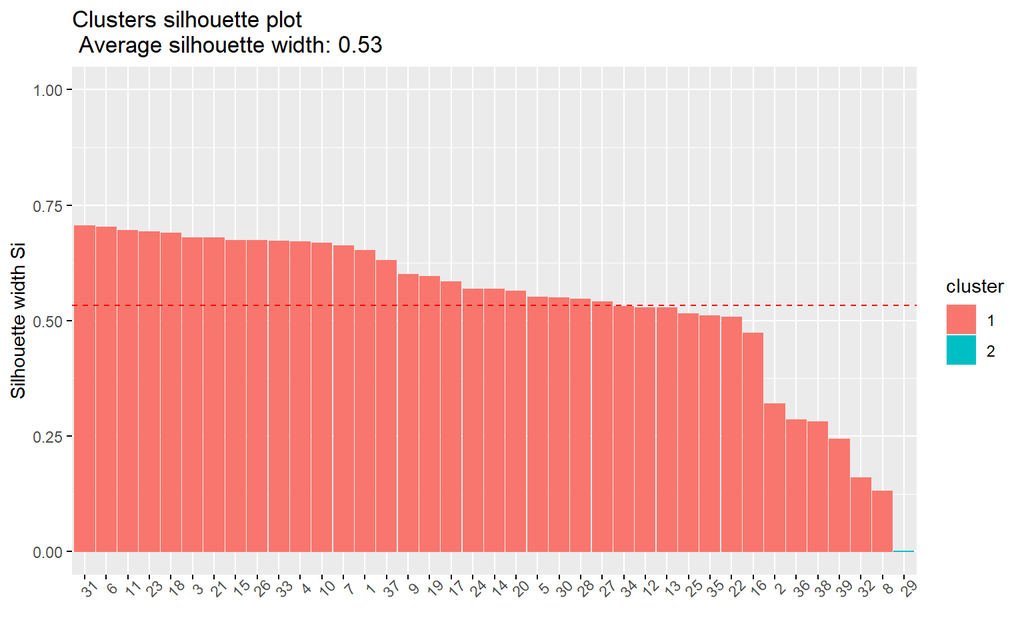

```r
fviz_silhouette(divisivo, label=TRUE)
```

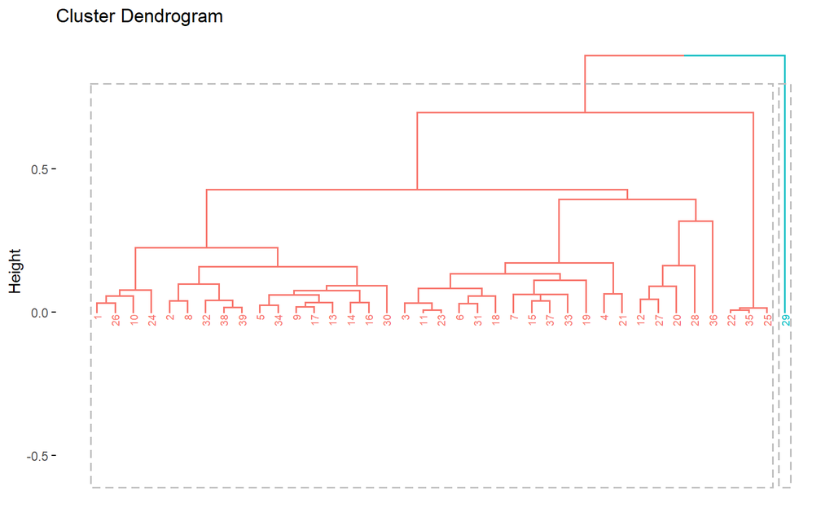

```r
fviz_dend(divisivo, rect = TRUE, cex = 0.5)
```

```r
diana$divisivo = divisivo$cluster
diana$divisivo = as.factor(diana$divisivo)
levels(diana$divisivo) = c("Bajo nivel de victimización", "Alto nivel de victimización")
table(diana$divisivo)
```

```
##
## Bajo nivel de victimización Alto nivel de victimización
##                          38                           1
```

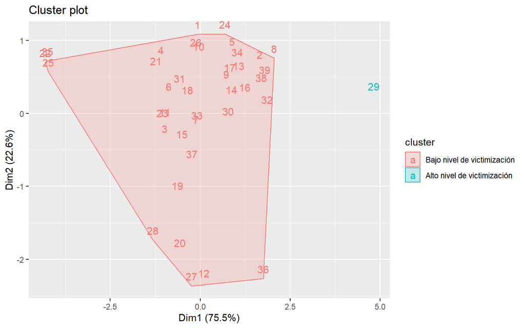

```r
fviz_cluster(object = list(data=vict_dist_1[,1:4], cluster = diana$divisivo),
             geom = c("text"),
             ellipse.type = "convex")
```

## Mapa de clasificación por baja o alta victmización (diana)

```r
names(diana)[names(diana) == 'NOMBREDI'] <- 'DISTRITO'
```

```r
data_mapa2 <- shp_lima  |>
  left_join(diana)
```

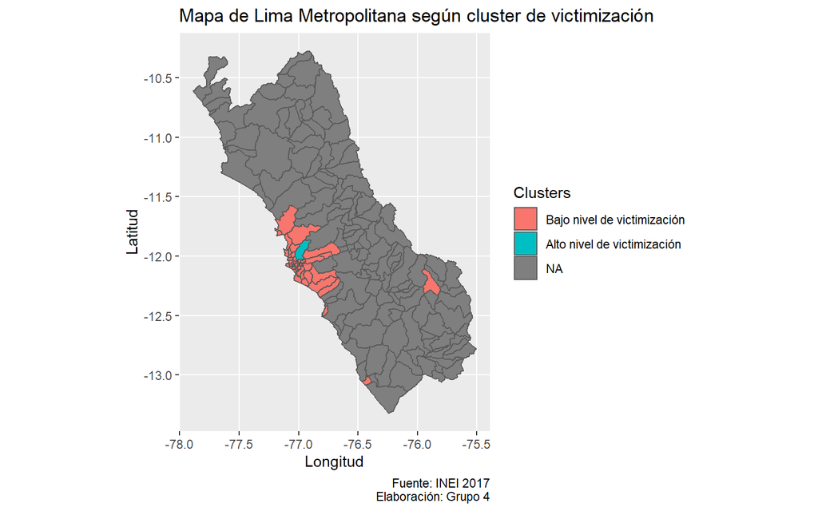

```r
ggplot(data_mapa2) +
  geom_sf(aes(fill = as.factor(divisivo)))+
  labs(title = "Mapa de Lima Metropolitana según cluster de victimización",
       caption = "Fuente: INEI 2017
       Elaboración: Grupo 4",
       x="Longitud",
       y="Latitud") +
  scale_fill_discrete(name = "Clusters")
```

# Bibliografía

### COSTA, Gino y CARLOS Romero. 2011. Inseguridad en el Perú:¿ qué hacer?. Lima: Ciudad Nuestra.

### LOPEZ, Noam. 2014. Inseguridad y percepción de inseguridad en Lima, Perú. Lima: Instituto de Opinión Pública de la Pontificia Universidad Católica del Perú.